# Reproducible Research: Project 1

The data set can be found [here](https://d396qusza40orc.cloudfront.net/repdata%2Fdata%2Factivity.zip). I have stored this in my local working directory as activity.csv.

First I will load the relevant libraries needed.

```r
library(ggplot2)
library(dplyr)
```

## 1. Loading the dataset

Here I read the data into R and convert the columns into the right format.

```r
data <- read.csv("activity.csv", header = TRUE)
data$date <- as.Date(data$date)
```

## 2. Data summary

Our first task is to analyse some basic summary statistics. We are interested in the following questions:

- How many steps are taken each day?
- What is the mean and median number of steps taken per day?

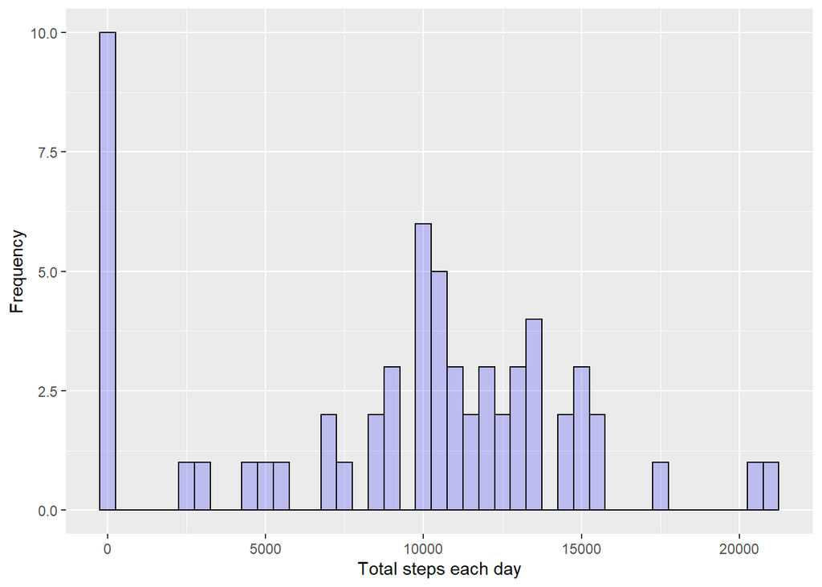

```r
# First we summarise the data
data_sum <- with(data, aggregate(steps, by = list(date), FUN = sum, na.rm = TRUE))
names(data_sum) <- c("Date", "Total_steps")

# Next we can plot this and obtain summary statistics
ggplot(data_sum, aes(x = Total_steps)) +
    geom_histogram(binwidth = 500,
                   color = "black", fill = "blue", alpha = .2) +
    labs(x = "Total steps each day", y = "Frequency")
```

```r
mean(data_sum$Total_steps)
```

```
## [1] 9354.23
```

```r
median(data_sum$Total_steps)
```

```
## [1] 10395
```

## 3. Average daily pattern

Next we want to investigate how the average daily pattern occurs. Here we first take the average steps taken at each interval:

```r
daily_pattern <- with(data, aggregate(x = list(step_mean = steps), by = list(interval = interval), FUN = mean, na.rm = TRUE))
```

We can look at this in a plot to see how the number of steps progress throughout an average day:

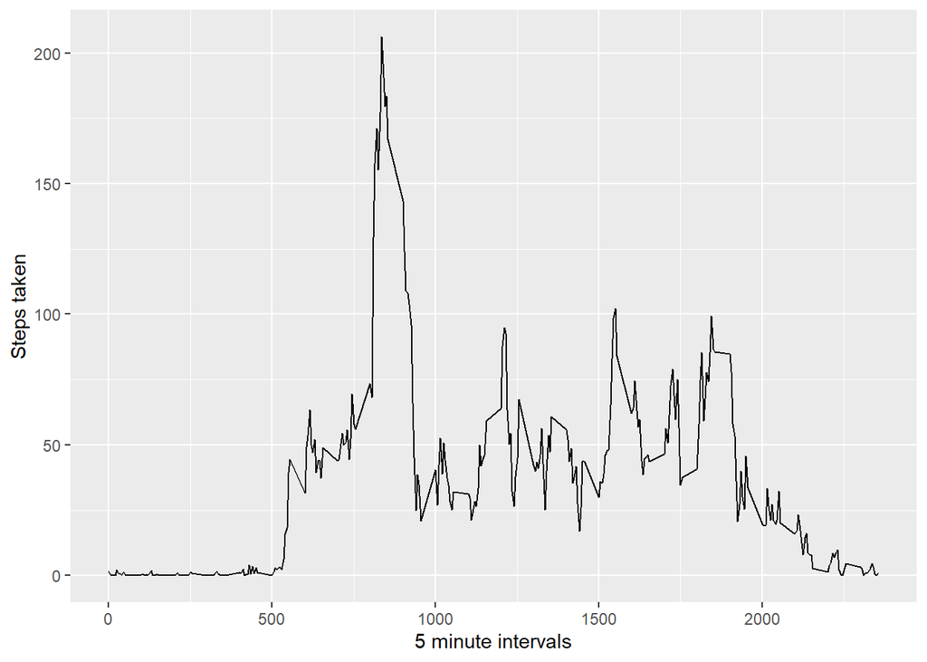

```r
ggplot(daily_pattern, aes(x = interval, y = step_mean)) +
    geom_line() +
    labs(x = "5 minute intervals", y = "Steps taken")
```

Next we want to know at which interval the maximum number of steps is taken.

```r
max_int <- daily_pattern[which.max(daily_pattern$step_mean), 1]
max_int
```

```
## [1] 835
```

## 4. Resolving missing values

We can see the number of missing values by looking at a summary table for the number of steps.

```r
mv_number <- sum(is.na(data$steps))
mv_number
```

```
## [1] 2304
```

So there are 2304 missing values in the dataset.

```r
# First add a temporary 4th column which has the means for each interval
data_joined <- left_join(data, daily_pattern)
# Then we will replace any NAs with the value in the temporary column
data_na_replaced <- data_joined %>% mutate(steps = ifelse(is.na(steps), step_mean, steps))

# Finally remove the temporary column
data_na_replaced <- data_na_replaced[, 1:3]
```

Now let us produce the same data summary as in 2. and see if there are any changes.

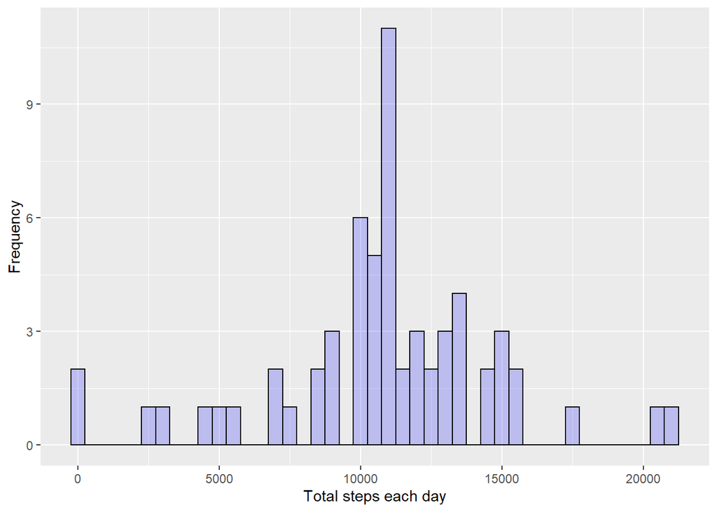

```r
# First we summarise the data
data_sum_na_replaced <- with(data_na_replaced, aggregate(steps, by = list(date), FUN = sum))
names(data_sum_na_replaced) <- c("Date", "Total_steps")

# Next we can plot this and obtain summary statistics
ggplot(data_sum_na_replaced, aes(x = Total_steps)) +
    geom_histogram(binwidth = 500,
                   color = "black", fill = "blue", alpha = .2) +
    labs(x = "Total steps each day", y = "Frequency")
```

```r
mean(data_sum_na_replaced$Total_steps)
```

```
## [1] 10766.19
```

```r
median(data_sum_na_replaced$Total_steps)
```

```
## [1] 10766.19
```

## 5. Analysis by weekdays / weekend

Finally, we are interested in whether the behaviour is different between weekdays or weekends.

We will check whether each date is a weekday or a weekend, and then plot the average pattern.

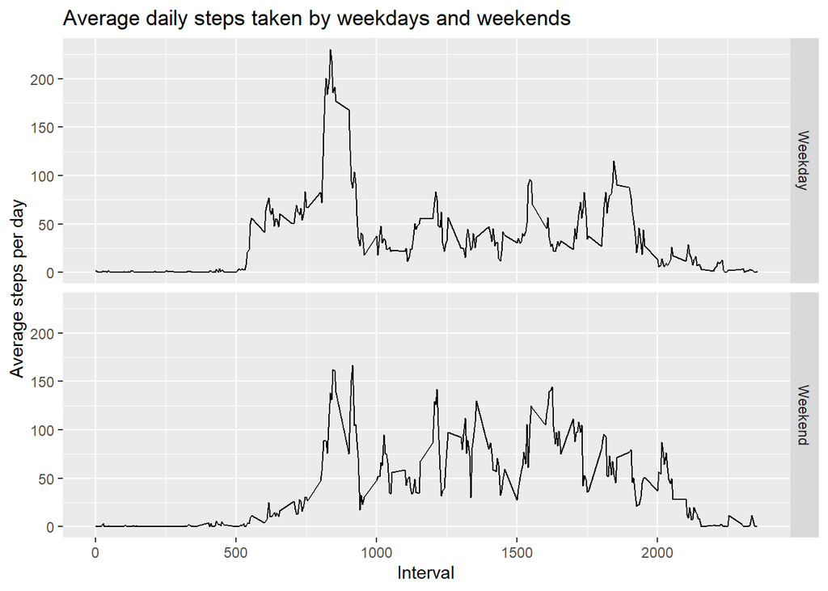

```r
# First let us determine whether each date is in a weekday or weekend
data_na_replaced <- data_na_replaced %>% mutate(is_weekday = weekdays(date))
weekday_list <- c("Monday", "Tuesday", "Wednesday", "Thursday", "Friday")
data_na_replaced$date_type <- ifelse(data_na_replaced$is_weekday %in% weekday_list, "Weekday", "Weekend")
data_na_replaced$date_type <- as.factor(data_na_replaced$date_type)

data_wk_avg <- with(data_na_replaced,
                    aggregate(x = list(steps_mean = steps),
                              by = list(interval = interval, date_type = date_type), mean))
ggplot(data_wk_avg, aes(x = interval, y = steps_mean)) +
    geom_line() +
    facet_grid(date_type ~ .) +
    labs(x = "Interval", y = "Average steps per day",
         title = "Average daily steps taken by weekdays and weekends")
```